# **Used Cars Price Prediction**

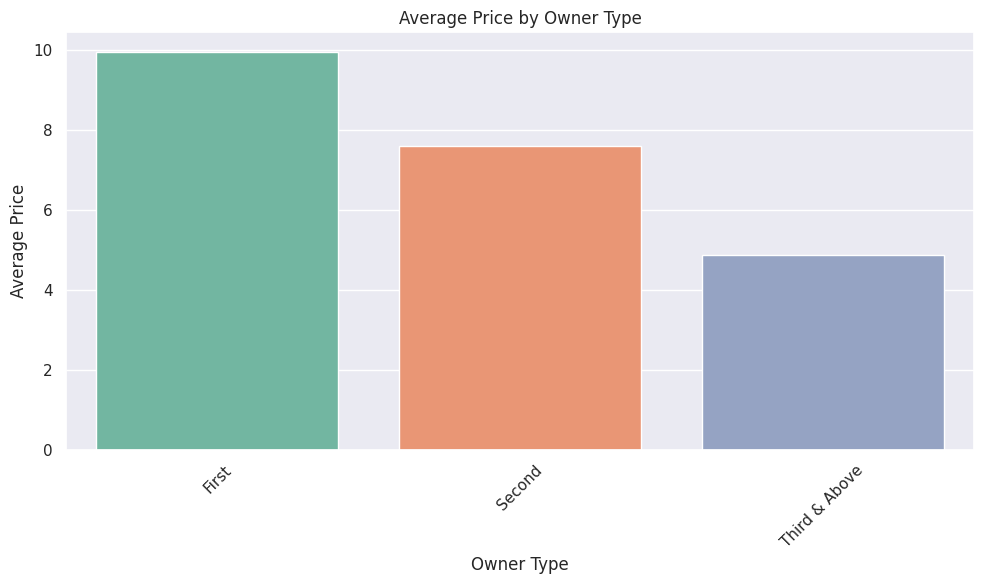

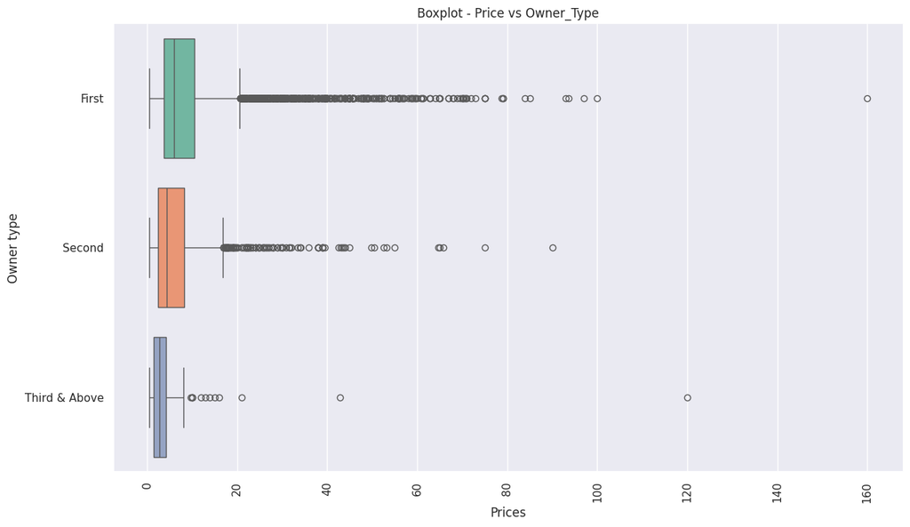

```python
# Group data by "Owner_Type" and calculate the average price
df_avg_price_owner = df.groupby("Owner_Type")["Price"].mean().reset_index()

plt.figure(figsize=[10, 6])
plt.xticks(rotation=45)

# Create bar plot
bar_plot = sns.barplot(x='Owner_Type', y='Price', data=df_avg_price_owner, palette='Set2')

# Set plot title and axis labels
plt.title('Average Price by Owner Type')
plt.xlabel('Owner Type')
plt.ylabel('Average Price')

# Show plot
plt.tight_layout()
plt.show()

# Set figure size
plt.figure(figsize=[14, 8])

# Create box plot
sns.boxplot(data=df, x='Price', y='Owner_Type', palette='Set2')

# Rotate x-axis labels for better readability
plt.xticks(rotation=90)

# Set plot title and axis labels
plt.title("Boxplot - Price vs Owner_Type")
plt.xlabel("Prices")
plt.ylabel("Owner type")

# Show plot
plt.show()
```

**Observations:**

### **Feature Engineering**

**Think about it:** The `Name` column in the current format might not be very useful in our analysis. Since the name contains both the brand name and the model name of the vehicle, the column would have too many unique values to be useful in prediction. Can we extract that information from that column?

- **Hint:** With 2041 unique names, car names are not going to be great predictors of the price in our current data. But we can process this column to extract important information for example brand name.

```python
# Extract Brand Names
df["Brand"] = df["Name"].apply(lambda x: x.split(" ")[0].lower())
df['Brand'].head()
```

```
0     maruti
1    hyundai
2      honda
3     maruti
4       audi
Name: Brand, dtype: object
```

```python
# Extract Model Names
df["Model"] = df["Name"].apply(lambda x: ' '.join(x.split(" ")[1:]).lower())
df['Model'].head()
```

```
0               wagon r lxi cng
1      creta 1.6 crdi sx option
2                        jazz v
3                    ertiga vdi
4    a4 new 2.0 tdi multitronic
Name: Model, dtype: object
```

```python
# Group Values by 'Brand' and apply aggregation function to display several values for Price concerning the Brand
brand_stats_price = df.groupby('Brand').agg({
    'Price': ['max', 'min', 'mean', 'median', 'count'],
    'Power': ['max', 'min', 'mean', 'median'],
    'Engine': ['max', 'min', 'mean', 'median'],
    'Mileage': ['max', 'min', 'mean', 'median'],
    })

# Sort values by highest mean price
brand_stats_price_sorted = brand_stats_price.sort_values(by = ('Power', 'max'), ascending=False)
brand_stats_price_sorted
```

| Brand | Price max | Price min | Price mean | Price median | Price count | Power max | Power min | Power mean | Power median | Engine max | Engine min | Engine mean | Engine median | Mileage max | Mileage min | Mileage mean | Mileage median |
| --- | --- | --- | --- | --- | --- | --- | --- | --- | --- | --- | --- | --- | --- | --- | --- | --- | --- |
| bentley | 59.00 | 59.00 | 59.000000 | 59.000 | 1 | 616.00 | 552.00 | 584.000000 | 584.000 | 5998.0 | 5998.0 | 5998.000000 | 5998.0 | 10.20 | 8.60 | 9.400000 | 9.400 |
| lamborghini | 120.00 | 120.00 | 120.000000 | 120.000 | 1 | 560.00 | 560.00 | 560.000000 | 560.000 | 5204.0 | 5204.0 | 5204.000000 | 5204.0 | 6.40 | 6.40 | 6.400000 | 6.400 |
| porsche | 75.00 | 2.02 | 48.348333 | 47.020 | 18 | 550.00 | 240.00 | 325.917647 | 300.000 | 4806.0 | 2706.0 | 3452.684211 | 2967.0 | 18.18 | 7.50 | 13.601579 | 15.150 |
| jaguar | 100.00 | 16.00 | 37.632250 | 31.900 | 40 | 503.00 | 177.00 | 236.216458 | 212.550 | 5000.0 | 1997.0 | 2571.750000 | 2179.0 | 19.33 | 9.43 | 14.889375 | 14.740 |
| bmw | 93.67 | 6.30 | 25.093684 | 21.000 | 266 | 450.00 | 143.00 | 210.573322 | 190.000 | 4395.0 | 1995.0 | 2328.424342 | 1995.0 | 22.69 | 7.94 | 16.979260 | 17.050 |
| audi | 72.94 | 7.50 | 25.537712 | 23.500 | 236 | 444.00 | 132.00 | 189.340246 | 174.330 | 4134.0 | 1395.0 | 2245.452632 | 1968.0 | 20.38 | 8.30 | 15.414225 | 15.730 |
| mercedes-benz | 90.00 | 3.90 | 26.809874 | 24.000 | 318 | 421.00 | 107.30 | 193.620820 | 186.000 | 5461.0 | 1595.0 | 2356.773684 | 2143.0 | 20.00 | 7.81 | 14.466339 | 14.210 |
| ford | 56.80 | 0.69 | 6.889400 | 5.345 | 300 | 395.00 | 67.00 | 96.364490 | 89.840 | 4951.0 | 999.0 | 1583.575499 | 1498.0 | 26.10 | 10.90 | 18.529171 | 18.880 |
| land | 160.00 | 11.00 | 39.259500 | 35.000 | 60 | 335.30 | 115.00 | 188.745937 | 187.700 | 4367.0 | 1999.0 | 2468.703125 | 2179.0 | 18.00 | 10.20 | 12.831053 | 12.700 |
| nissan | 8.92 | 1.75 | 4.738352 | 4.300 | 91 | 328.50 | 63.10 | 89.702478 | 84.800 | 3696.0 | 1198.0 | 1492.837607 | 1461.0 | 23.19 | 9.10 | 19.229915 | 19.340 |
| skoda | 27.30 | 1.25 | 7.559075 | 6.000 | 173 | 262.60 | 66.00 | 126.622750 | 108.495 | 3597.0 | 1198.0 | 1782.089552 | 1798.0 | 21.72 | 9.30 | 17.066200 | 17.200 |
| honda | 17.50 | 0.90 | 5.411743 | 4.950 | 608 | 218.00 | 78.00 | 108.450707 | 98.600 | 2997.0 | 1198.0 | 1503.194030 | 1497.0 | 27.40 | 9.00 | 18.556563 | 17.800 |
| volvo | 32.50 | 7.25 | 18.802857 | 18.250 | 21 | 215.00 | 150.00 | 188.464286 | 190.000 | 2400.0 | 1969.0 | 2175.607143 | 1985.0 | 27.03 | 9.00 | 15.030714 | 13.500 |
| mitsubishi | 28.00 | 1.00 | 11.058889 | 9.950 | 27 | 199.30 | 68.00 | 145.193333 | 172.780 | 3200.0 | 1468.0 | 2542.027778 | 2477.0 | 14.80 | 9.50 | 12.291667 | 13.500 |
| hyundai | 23.00 | 0.45 | 5.343433 | 4.600 | 1107 | 198.25 | 55.00 | 92.152134 | 82.000 | 2359.0 | 814.0 | 1306.604354 | 1197.0 | 25.40 | 11.40 | 19.245200 | 18.900 |
| mini | 39.75 | 17.00 | 26.896923 | 24.285 | 26 | 192.00 | 112.00 | 146.656774 | 113.980 | 1998.0 | 1496.0 | 1758.645161 | 1598.0 | 23.80 | 13.60 | 18.581935 | 18.860 |
| volkswagen | 24.90 | 2.10 | 5.307270 | 4.890 | 315 | 189.00 | 73.75 | 94.761220 | 103.200 | 1984.0 | 999.0 | 1438.783422 | 1498.0 | 22.07 | 10.98 | 18.337346 | 17.210 |
| mahindra | 17.63 | 1.50 | 8.027638 | 7.570 | 271 | 184.00 | 62.10 | 119.709509 | 120.000 | 2696.0 | 1198.0 | 2126.638298 | 2179.0 | 25.32 | 10.50 | 15.305535 | 15.100 |
| toyota | 35.82 | 1.50 | 11.577171 | 10.750 | 410 | 178.40 | 67.04 | 128.330561 | 132.000 | 2982.0 | 1197.0 | 2302.061630 | 2494.0 | 23.59 | 11.00 | 14.502619 | 12.990 |
| isuzu | 20.00 | 8.00 | 14.696667 | 16.090 | 3 | 174.57 | 134.00 | 147.514000 | 134.000 | 2999.0 | 2499.0 | 2699.000000 | 2499.0 | 13.80 | 12.08 | 12.616000 | 12.400 |
| jeep | 23.91 | 15.00 | 18.718667 | 18.500 | 15 | 170.00 | 160.00 | 168.947368 | 170.000 | 1956.0 | 1368.0 | 1894.105263 | 1956.0 | 17.10 | 16.00 | 16.731579 | 17.100 |
| chevrolet | 9.87 | 0.75 | 3.044463 | 2.500 | 121 | 163.70 | 56.30 | 90.909333 | 79.400 | 2499.0 | 936.0 | 1370.125828 | 1199.0 | 25.44 | 11.50 | 18.306556 | 18.100 |
| maruti | 11.50 | 0.45 | 4.517267 | 4.150 | 1211 | 163.50 | 34.20 | 74.000007 | 74.000 | 2393.0 | 793.0 | 1146.933613 | 1197.0 | 33.54 | 9.70 | 21.510464 | 21.100 |
| fiat | 7.71 | 0.55 | 3.269286 | 2.600 | 28 | 160.00 | 67.00 | 89.028125 | 90.600 | 1368.0 | 1172.0 | 1274.000000 | 1248.0 | 21.20 | 14.40 | 17.859459 | 19.000 |
| tata | 17.85 | 0.44 | 3.562849 | 2.900 | 186 | 154.00 | 35.00 | 78.281652 | 74.000 | 2956.0 | 624.0 | 1331.640351 | 1248.0 | 27.28 | 11.57 | 19.946886 | 20.475 |
| renault | 14.01 | 2.40 | 5.799034 | 5.490 | 145 | 148.00 | 53.30 | 87.510471 | 83.800 | 1997.0 | 799.0 | 1321.235294 | 1461.0 | 25.17 | 13.06 | 20.727471 | 19.870 |
| force | 12.00 | 8.00 | 9.333333 | 8.000 | 3 | 139.07 | 139.01 | 139.030000 | 139.010 | 2200.0 | 2149.0 | 2183.000000 | 2200.0 | 17.00 | 17.00 | 17.000000 | 17.000 |
| opelcorsa | NaN | NaN | NaN | NaN | 0 | 88.00 | 88.00 | 88.000000 | 88.000 | 1389.0 | 1389.0 | 1389.000000 | 1389.0 | 14.20 | 14.20 | 14.200000 | 14.200 |
| datsun | 3.95 | 2.25 | 3.049231 | 3.100 | 13 | 67.06 | 53.00 | 60.644706 | 67.000 | 1198.0 | 799.0 | 1010.235294 | 1198.0 | 22.70 | 19.44 | 21.345294 | 20.630 |
| ambassador | 1.35 | 1.35 | 1.350000 | 1.350 | 1 | 35.50 | 35.50 | 35.500000 | 35.500 | 1489.0 | 1489.0 | 1489.000000 | 1489.0 | 12.80 | 12.80 | 12.800000 | 12.800 |
| hindustan | NaN | NaN | NaN | NaN | 0 | NaN | NaN | NaN | NaN | 1995.0 | 1995.0 | 1995.000000 | 1995.0 | 14.10 | 14.10 | 14.100000 | 14.100 |
| smart | 3.00 | 3.00 | 3.000000 | 3.000 | 1 | NaN | NaN | NaN | NaN | 799.0 | 799.0 | 799.000000 | 799.0 | NaN | NaN | NaN | NaN |

```python
# Filter the DataFrame for smart Brand
df[df['Brand'] == 'smart']
```

|  | Name | Location | Kilometers_Driven | Fuel_Type | Transmission | Owner_Type | Mileage | Engine | Power | Seats | Price | Age | kilometers_driven_log | Price_log | Brand | Model |
| --- | --- | --- | --- | --- | --- | --- | --- | --- | --- | --- | --- | --- | --- | --- | --- | --- |
| 915 | Smart Fortwo CDI AT | Pune | 103000 | Diesel | Automatic | Second | NaN | 799.0 | NaN | 2.0 | 3.0 | 16 | 11.542484 | 1.098612 | smart | fortwo cdi at |

```python
# Drop rows where 'Brand' is equal to 'smart'
df.drop(df[df['Brand'] == 'smart'].index, inplace=True)
```

**Observations:**

### **Missing value treatment**

**Missing values of Seats**

```python
# We get the first 5 datapoints were the seats variable is null
df[df['Seats'].isnull()].head()
```

|  | Name | Location | Kilometers_Driven | Fuel_Type | Transmission | Owner_Type | Mileage | Engine | Power | Seats | Price | Age | kilometers_driven_log | Price_log | Brand | Model |
| --- | --- | --- | --- | --- | --- | --- | --- | --- | --- | --- | --- | --- | --- | --- | --- | --- |
| 194 | Honda City 1.5 GXI | Ahmedabad | 60006 | Petrol | Manual | First | NaN | NaN | NaN | NaN | 2.95 | 17 | 11.002200 | 1.081805 | honda | city 1.5 gxi |
| 208 | Maruti Swift 1.3 VXi | Kolkata | 42001 | Petrol | Manual | First | 16.1 | NaN | NaN | NaN | 2.11 | 14 | 10.645449 | 0.746688 | maruti | swift 1.3 vxi |
| 229 | Ford Figo Diesel | Bangalore | 70436 | Diesel | Manual | First | NaN | 1498.0 | 99.0 | NaN | 3.60 | 9 | 11.162460 | 1.280934 | ford | figo diesel |
| 733 | Maruti Swift 1.3 VXi | Chennai | 97800 | Petrol | Manual | Third & Above | 16.1 | NaN | NaN | NaN | 1.75 | 18 | 11.490680 | 0.559616 | maruti | swift 1.3 vxi |
| 749 | Land Rover Range Rover 3.0 D | Mumbai | 55001 | Diesel | Automatic | Second | NaN | NaN | NaN | NaN | 26.50 | 16 | 10.915107 | 3.277145 | land | rover range rover 3.0 d |

```python
# We print the data points were the model is equal to the one with the missing value on seat and we also compute de median for both Model and Brand
print(df[df['Brand'] == 'honda']['Seats'].median())
print(df[df['Model'] == 'city 1.5 gxi']['Seats'].median())
df[df['Model'] == 'city 1.5 gxi']
```

```
5.0
5.0
```

|  | Name | Location | Kilometers_Driven | Fuel_Type | Transmission | Owner_Type | Mileage | Engine | Power | Seats | Price | Age | kilometers_driven_log | Price_log | Brand | Model |
| --- | --- | --- | --- | --- | --- | --- | --- | --- | --- | --- | --- | --- | --- | --- | --- | --- |
| 194 | Honda City 1.5 GXI | Ahmedabad | 60006 | Petrol | Manual | First | NaN | NaN | NaN | NaN | 2.95 | 17 | 11.002200 | 1.081805 | honda | city 1.5 gxi |
| 1385 | Honda City 1.5 GXI | Pune | 115000 | Petrol | Manual | Second | NaN | NaN | NaN | NaN | 1.50 | 20 | 11.652687 | 0.405465 | honda | city 1.5 gxi |
| 3305 | Honda City 1.5 GXI | Jaipur | 75055 | Petrol | Manual | First | 12.8 | 1493.0 | 100.0 | 5.0 | 2.30 | 17 | 11.225976 | 0.832909 | honda | city 1.5 gxi |
| 4767 | Honda City 1.5 GXI | Mumbai | 81000 | Petrol | Manual | Second | 12.8 | 1493.0 | 100.0 | 5.0 | 1.10 | 19 | 11.302204 | 0.095310 | honda | city 1.5 gxi |
| 5270 | Honda City 1.5 GXI | Bangalore | 53000 | Petrol | Manual | Second | NaN | NaN | NaN | NaN | 1.85 | 22 | 10.878047 | 0.615186 | honda | city 1.5 gxi |

Reviewing the data we can see we can get the number of seats of the cars using their brand and model, computing the median

```python
# Calculate the median seats for each model
median_seats_by_model = df.groupby('Model')['Seats'].transform('median')

# Fill null values in 'Seats' column with corresponding median seats by model
df['Seats'] = df['Seats'].fillna(median_seats_by_model)

print('Null values with using model ',df['Seats'].isnull().sum())
# Calculate the median seats for each brand
median_seats_by_brand = df.groupby('Brand')['Seats'].transform('median')

# Fill remaining null values in 'Seats' column with corresponding median seats by brand
df['Seats'] = df['Seats'].fillna(median_seats_by_brand)

print('Null values with using model and brand ',df['Seats'].isnull().sum())

df['Seats'].value_counts()
```

```
Null values with using model  46
Null values with using model and brand  0
```

```
Seats
5.0     6096
7.0      798
8.0      170
4.0      119
6.0       38
2.0       17
10.0       8
9.0        3
Name: count, dtype: int64
```

**Missing values of Mileage**

```python
df['Mileage'].isnull().sum()
```

```
80
```

```python
# Calculate the median of power for each model
median_power_by_mileage = df.groupby('Model')['Mileage'].transform('median')

# Fill null values in 'Power' column with corresponding median power by model
df['Mileage'] = df['Mileage'].fillna(median_power_by_mileage)

print('Null values with using model ',df['Mileage'].isnull().sum())

# Calculate the median power for each brand
median_power_by_mileage = df.groupby('Brand')['Mileage'].transform('median')

# Fill remaining null values in 'Power' column with corresponding median power by brand
df['Mileage'] = df['Mileage'].fillna(median_power_by_mileage)

print('Null values with using model and brand ',df['Mileage'].isnull().sum())
```

```
Null values with using model  77
Null values with using model and brand  0
```

```python
df['Mileage'] = df['Mileage'].fillna(df['Mileage'].median())
df['Mileage'].isnull().sum()
```

```
0
```

**Missing values of Engine**

```python
df['Engine'].isnull().sum()
```

```
46
```

```python
# Calculate the median of engine for each model
median_engine_by_model = df.groupby('Model')['Engine'].transform('median')

# Fill null values in 'Engine' column with corresponding median engine by model
df['Engine'] = df['Engine'].fillna(median_engine_by_model)

print('Null values with using model ',df['Engine'].isnull().sum())

# Calculate the median seats for each brand
median_engine_by_brand = df.groupby('Brand')['Engine'].transform('median')

# Fill remaining null values in 'Seats' column with corresponding median seats by brand
df['Engine'] = df['Engine'].fillna(median_engine_by_brand)

print('Null values with using model and brand ',df['Engine'].isnull().sum())
```

```
Null values with using model  40
Null values with using model and brand  0
```

**Missing values of Power**

```python
# Calculate the median of power for each model
median_power_by_model = df.groupby('Model')['Power'].transform('median')

# Fill null values in 'Power' column with corresponding median power by model
df['Power'] = df['Power'].fillna(median_power_by_model)

print('Null values with using model ',df['Power'].isnull().sum())

# Calculate the median power for each brand
median_power_by_brand = df.groupby('Brand')['Power'].transform('median')

# Fill remaining null values in 'Power' column with corresponding median power by brand
df['Power'] = df['Power'].fillna(median_power_by_brand)

print('Null values with using model and brand ',df['Power'].isnull().sum())
```

```
Null values with using model  135
Null values with using model and brand  1
```

```python
df.groupby('Brand')['Power'].median()
```

```
Brand
ambassador        35.500
audi             174.330
bentley          584.000
bmw              190.000
chevrolet         79.400
datsun            67.000
fiat              90.600
force            139.010
ford              89.840
hindustan            NaN
honda             98.600
hyundai           82.000
isuzu            134.000
jaguar           212.550
jeep             170.000
lamborghini      560.000
land             187.700
mahindra         120.000
maruti            74.000
mercedes-benz    186.000
mini             113.980
mitsubishi       172.780
nissan            84.800
opelcorsa         88.000
porsche          300.000
renault           83.800
skoda            108.495
tata              74.000
toyota           125.000
volkswagen       103.200
volvo            190.000
Name: Power, dtype: float64
```

```python
df['Power'] = df['Power'].fillna(df['Power'].median())
df['Power'].isnull().sum()
```

```
0
```

**Missing values of Price**

```python
df['Price'].isnull().sum()
```

```
1234
```

We will drop the rows that have null values in price

```python
df.dropna(subset=['Price'], inplace=True)
df['Price'].isnull().sum()
```

```
0
```

```python
df.isnull().sum()
```

```
Name                     0
Location                 0
Kilometers_Driven        0
Fuel_Type                0
Transmission             0
Owner_Type               0
Mileage                  0
Engine                   0
Power                    0
Seats                    0
Price                    0
Age                      0
kilometers_driven_log    0
Price_log                0
Brand                    0
Model                    0
dtype: int64
```

## **Important Insights from EDA and Data Preprocessing**

What are the the most important observations and insights from the data based on the EDA and Data Preprocessing performed?

## **Building Various Models**

1. What we want to predict is the "Price". We will use the normalized version 'price_log' for modeling.
2. Before we proceed to the model, we'll have to encode categorical features. We will drop categorical features like Name.
3. We'll split the data into train and test, to be able to evaluate the model that we build on the train data.
4. Build Regression models using train data.
5. Evaluate the model performance.

### **Split the Data**

Step1: Seperating the indepdent variables (X) and the dependent variable (y).

Step2: Encode the categorical variables in X using pd.dummies.

Step3: Split the data into train and test using train_test_split.

**Question:**

1. Why we should drop 'Name','Price','price_log','Kilometers_Driven' from X before splitting?

R/ We dropped name because we transformed it into 2 variables (Brand and Model), we don't need Price because we transformed it using Log, Price_log is the label variable and Kilometers_Driven was also transformed with Log

```python
# We drop the Name column since we will use the Brand and Model
df.drop(columns=['Name'], inplace=True)
```

```python
df.info()
```

```
<class 'pandas.core.frame.DataFrame'>
Index: 6015 entries, 0 to 6018
Data columns (total 15 columns):
 #   Column                 Non-Null Count  Dtype
---  ------                 --------------  -----
 0   Location               6015 non-null   object
 1   Kilometers_Driven      6015 non-null   int64
 2   Fuel_Type              6015 non-null   object
 3   Transmission           6015 non-null   object
 4   Owner_Type             6015 non-null   object
 5   Mileage                6015 non-null   float64
 6   Engine                 6015 non-null   float64
 7   Power                  6015 non-null   float64
 8   Seats                  6015 non-null   float64
 9   Price                  6015 non-null   float64
 10  Age                    6015 non-null   int64
 11  kilometers_driven_log  6015 non-null   float64
 12  Price_log              6015 non-null   float64
 13  Brand                  6015 non-null   object
 14  Model                  6015 non-null   object
dtypes: float64(7), int64(2), object(6)
memory usage: 751.9+ KB
```

```python
# Separating features and the target column
X = df.drop(['Price','Price_log','Kilometers_Driven','Model'], axis = 1)
y = df["Price_log"]

def encode_cat_vars(x):
    # Get dummy variables
    dummies = pd.get_dummies(
        x,
        columns=x.select_dtypes(include=["object"]).columns.tolist(),
        drop_first=True,
    )

    # Convert True/False to 1/0
    dummies = dummies.astype(int)

    return dummies
#create dummy variable
X = encode_cat_vars(X)
X.head()
```

|  | Mileage | Engine | Power | Seats | Age | kilometers_driven_log | Location_Bangalore | Location_Chennai | Location_Coimbatore | Location_Delhi | ... | Brand_mini | Brand_mitsubishi | Brand_nissan | Brand_porsche | Brand_renault | Brand_skoda | Brand_tata | Brand_toyota | Brand_volkswagen | Brand_volvo |
| --- | --- | --- | --- | --- | --- | --- | --- | --- | --- | --- | --- | --- | --- | --- | --- | --- | --- | --- | --- | --- | --- |
| 0 | 26 | 998 | 58 | 5 | 14 | 11 | 0 | 0 | 0 | 0 | ... | 0 | 0 | 0 | 0 | 0 | 0 | 0 | 0 | 0 | 0 |
| 1 | 19 | 1582 | 126 | 5 | 9 | 10 | 0 | 0 | 0 | 0 | ... | 0 | 0 | 0 | 0 | 0 | 0 | 0 | 0 | 0 | 0 |
| 2 | 18 | 1199 | 88 | 5 | 13 | 10 | 0 | 1 | 0 | 0 | ... | 0 | 0 | 0 | 0 | 0 | 0 | 0 | 0 | 0 | 0 |
| 3 | 20 | 1248 | 88 | 7 | 12 | 11 | 0 | 1 | 0 | 0 | ... | 0 | 0 | 0 | 0 | 0 | 0 | 0 | 0 | 0 | 0 |
| 4 | 15 | 1968 | 140 | 5 | 11 | 10 | 0 | 0 | 1 | 0 | ... | 0 | 0 | 0 | 0 | 0 | 0 | 0 | 0 | 0 | 0 |

5 rows × 49 columns

```python
X = sm.add_constant(X)

# Splitting the data into train and test sets in 70:30 ratio
X_train, X_test, y_train, y_test = train_test_split(
    X, y, test_size = 0.30, random_state = 1)

print(X_train.shape, X_test.shape)

X_train.head()
```

```
(4210, 50) (1805, 50)
```

|  | const | Mileage | Engine | Power | Seats | Age | kilometers_driven_log | Location_Bangalore | Location_Chennai | Location_Coimbatore | ... | Brand_mini | Brand_mitsubishi | Brand_nissan | Brand_porsche | Brand_renault | Brand_skoda | Brand_tata | Brand_toyota | Brand_volkswagen | Brand_volvo |
| --- | --- | --- | --- | --- | --- | --- | --- | --- | --- | --- | --- | --- | --- | --- | --- | --- | --- | --- | --- | --- | --- |
| 3647 | 1.0 | 25 | 1186 | 73 | 5 | 7 | 11 | 0 | 0 | 0 | ... | 0 | 0 | 0 | 0 | 0 | 0 | 0 | 0 | 0 | 0 |
| 1519 | 1.0 | 28 | 1248 | 73 | 5 | 7 | 10 | 0 | 0 | 0 | ... | 0 | 0 | 0 | 0 | 0 | 0 | 0 | 0 | 0 | 0 |
| 5998 | 1.0 | 17 | 1198 | 73 | 5 | 14 | 11 | 0 | 0 | 0 | ... | 0 | 0 | 0 | 0 | 0 | 0 | 0 | 0 | 1 | 0 |
| 685 | 1.0 | 21 | 1248 | 73 | 5 | 12 | 11 | 0 | 0 | 0 | ... | 0 | 0 | 0 | 0 | 0 | 0 | 0 | 0 | 0 | 0 |
| 5665 | 1.0 | 18 | 1197 | 82 | 5 | 9 | 10 | 0 | 0 | 0 | ... | 0 | 0 | 0 | 0 | 0 | 0 | 0 | 0 | 0 | 0 |

5 rows × 50 columns

**Check Multicollinearity**

```python
from statsmodels.stats.outliers_influence import variance_inflation_factor

# Function to check VIF
def checking_vif(train):
    vif = pd.DataFrame()
    vif["feature"] = train.columns

    # Calculating VIF for each feature
    vif["VIF"] = [
        variance_inflation_factor(train.values, i) for i in range(len(train.columns))
    ]
    return vif

print(checking_vif(X_train))
```

```
                     feature          VIF
0                      const  4761.867510
1                    Mileage     3.737754
2                     Engine    11.449129
3                      Power    10.468378
4                      Seats     2.528862
5                        Age     2.105259
6      kilometers_driven_log     1.636920
7         Location_Bangalore     2.577141
8           Location_Chennai     2.994788
9        Location_Coimbatore     3.519489
10            Location_Delhi     3.207531
11        Location_Hyderabad     3.889291
12           Location_Jaipur     2.740505
13            Location_Kochi     3.571716
```

[output cut: 36 more lines]

```python
# List of columns to drop
columns_to_drop = [col for col in X.columns if col.startswith('Brand_')]

# Drop the columns from the DataFrame
X = X.drop(columns_to_drop, axis=1)
```

```python
# Splitting the data into train and test sets in 70:30 ratio
X_train, X_test, y_train, y_test = train_test_split(
    X, y, test_size = 0.30, random_state = 1)
```

```python
print(checking_vif(X_train))
```

```
                     feature         VIF
0                      const  542.619359
1                    Mileage    3.173244
2                     Engine    9.058040
3                      Power    6.981529
4                      Seats    1.866476
5                        Age    1.995013
6      kilometers_driven_log    1.588110
7         Location_Bangalore    2.560001
8           Location_Chennai    2.967774
9        Location_Coimbatore    3.492768
10            Location_Delhi    3.183543
11        Location_Hyderabad    3.856691
12           Location_Jaipur    2.713933
13            Location_Kochi    3.553491
14          Location_Kolkata    3.192797
15           Location_Mumbai    4.059924
16             Location_Pune    3.338904
17             Fuel_Type_Gas    1.044590
18          Fuel_Type_Petrol    2.150301
19       Transmission_Manual    1.863842
20         Owner_Type_Second    1.183978
21  Owner_Type_Third & Above    1.123141
```

Engine and Power have a high VIF score, we will drop Engine and check again

```python
X = X.drop(['Engine'], axis = 1)
```

```python
# Splitting the data into train and test sets in 70:30 ratio
X_train, X_test, y_train, y_test = train_test_split(
    X, y, test_size = 0.30, random_state = 1)
```

```python
print(checking_vif(X_train))
```

```
                     feature         VIF
0                      const  531.637965
1                    Mileage    2.639925
2                      Power    2.598551
3                      Seats    1.606297
4                        Age    1.992729
5      kilometers_driven_log    1.587215
6         Location_Bangalore    2.559911
7           Location_Chennai    2.966345
8        Location_Coimbatore    3.491490
9             Location_Delhi    3.182799
10        Location_Hyderabad    3.854141
11           Location_Jaipur    2.713760
12            Location_Kochi    3.552347
13          Location_Kolkata    3.190832
14           Location_Mumbai    4.059866
15             Location_Pune    3.338320
16             Fuel_Type_Gas    1.043796
17          Fuel_Type_Petrol    1.753218
18       Transmission_Manual    1.848408
19         Owner_Type_Second    1.183887
20  Owner_Type_Third & Above    1.123049
```

All the VIF scores are acceptable below 5, this means there is no multicolinearity

```python
from sklearn.metrics import r2_score, mean_absolute_percentage_error, mean_absolute_error, mean_squared_error

# Model Performance on test and train data
def model_pref(olsmodel, x_train, x_test):

    # In-sample Prediction
    y_pred_train = olsmodel.predict(x_train)
    y_observed_train = y_train

    # Prediction on test data
    y_pred_test = olsmodel.predict(x_test)
    y_observed_test = y_test

    print(
        pd.DataFrame(
            {
                "Data": ["Train", "Test"],
                "RMSE": [
                    np.sqrt(mean_squared_error(y_pred_train, y_observed_train)),
                    np.sqrt(mean_squared_error(y_pred_test, y_observed_test)),
                ],
                "MAE": [
                    mean_absolute_error(y_pred_train, y_observed_train),
                    mean_absolute_error(y_pred_test, y_observed_test),
                ],

                "r2": [
                    r2_score(y_pred_train, y_observed_train),
                    r2_score(y_pred_test, y_observed_test),
                ],
            }
        )
    )
```

```python
print(X_train.shape, y_train.shape, X_test.shape, y_test.shape)
```

```
(4210, 21) (4210,) (1805, 21) (1805,)
```

```python
# Splitting the data in 70:30 ratio of train to test data
X_train, X_test, y_train, y_test = train_test_split(X, y, test_size = 0.30 , random_state = 1)
```

```python
# Create the model
model1 = sm.OLS(y_train, X_train).fit()
```

```python
# Get the model summary
model1.summary()
```

OLS Regression Results

| Dep. Variable: | Price_log | R-squared: | 0.884 |
| --- | --- | --- | --- |
| Model: | OLS | Adj. R-squared: | 0.884 |
| Method: | Least Squares | F-statistic: | 1599. |
| Date: | Thu, 11 Apr 2024 | Prob (F-statistic): | 0.00 |
| Time: | 17:11:49 | Log-Likelihood: | -910.95 |
| No. Observations: | 4210 | AIC: | 1864. |
| Df Residuals: | 4189 | BIC: | 1997. |
| Df Model: | 20 |  |  |
| Covariance Type: | nonrobust |  |  |

|  | coef | std err | t | P>\|t\| | [0.025 | 0.975] |
| --- | --- | --- | --- | --- | --- | --- |
| const | 3.6279 | 0.107 | 33.897 | 0.000 | 3.418 | 3.838 |
| Mileage | -0.0256 | 0.002 | -14.047 | 0.000 | -0.029 | -0.022 |
| Power | 0.0082 | 0.000 | 59.864 | 0.000 | 0.008 | 0.009 |
| Seats | 0.0163 | 0.007 | 2.217 | 0.027 | 0.002 | 0.031 |
| Age | -0.1158 | 0.002 | -58.462 | 0.000 | -0.120 | -0.112 |
| kilometers_driven_log | -0.0681 | 0.007 | -9.314 | 0.000 | -0.082 | -0.054 |
| Location_Bangalore | 0.1527 | 0.031 | 4.986 | 0.000 | 0.093 | 0.213 |
| Location_Chennai | -0.0027 | 0.029 | -0.092 | 0.927 | -0.060 | 0.055 |
| Location_Coimbatore | 0.0926 | 0.028 | 3.251 | 0.001 | 0.037 | 0.148 |
| Location_Delhi | -0.0485 | 0.029 | -1.693 | 0.090 | -0.105 | 0.008 |
| Location_Hyderabad | 0.1147 | 0.028 | 4.165 | 0.000 | 0.061 | 0.169 |
| Location_Jaipur | -0.0964 | 0.030 | -3.218 | 0.001 | -0.155 | -0.038 |
| Location_Kochi | -0.0383 | 0.028 | -1.351 | 0.177 | -0.094 | 0.017 |
| Location_Kolkata | -0.2507 | 0.029 | -8.685 | 0.000 | -0.307 | -0.194 |
| Location_Mumbai | -0.0556 | 0.028 | -2.020 | 0.043 | -0.110 | -0.002 |
| Location_Pune | -0.0675 | 0.029 | -2.362 | 0.018 | -0.124 | -0.011 |
| Fuel_Type_Gas | -0.2247 | 0.048 | -4.709 | 0.000 | -0.318 | -0.131 |
| Fuel_Type_Petrol | -0.3898 | 0.012 | -31.584 | 0.000 | -0.414 | -0.366 |
| Transmission_Manual | -0.2946 | 0.014 | -21.128 | 0.000 | -0.322 | -0.267 |
| Owner_Type_Second | -0.0776 | 0.014 | -5.670 | 0.000 | -0.104 | -0.051 |
| Owner_Type_Third & Above | -0.1151 | 0.034 | -3.422 | 0.001 | -0.181 | -0.049 |

| Omnibus: | 1064.585 | Durbin-Watson: | 2.054 |
| --- | --- | --- | --- |
| Prob(Omnibus): | 0.000 | Jarque-Bera (JB): | 14023.531 |
| Skew: | -0.831 | Prob(JB): | 0.00 |
| Kurtosis: | 11.785 | Cond. No. | 3.01e+03 |

Notes:  
[1] Standard Errors assume that the covariance matrix of the errors is correctly specified.  
[2] The condition number is large, 3.01e+03. This might indicate that there are  
strong multicollinearity or other numerical problems.

```python
# Checking model1 performance
model_pref(model1, X_train, X_test)
```

```
    Data      RMSE       MAE        r2
0  Train  0.300424  0.221318  0.869006
1   Test  0.281397  0.215928  0.874420
```

**Observations:**

### **Drop insignificant variables (variables with p-value > 0.05) from the above model and create the regression model again.**

```python
# List of columns to drop
columns_to_drop = [col for col in X.columns if col.startswith('Location_')]


# Drop the columns from the DataFrame
X = X.drop(columns_to_drop, axis=1)
X = sm.add_constant(X)
```

```python
# Splitting the data in 70:30 ratio of train to test data
X_train, X_test, y_train, y_test = train_test_split(X, y, test_size = 0.30 , random_state = 1)
```

```python
# Create the model
model2 = sm.OLS(y_train, X_train).fit()

# Get the model summary
model2.summary()
```

OLS Regression Results

| Dep. Variable: | Price_log | R-squared: | 0.871 |
| --- | --- | --- | --- |
| Model: | OLS | Adj. R-squared: | 0.870 |
| Method: | Least Squares | F-statistic: | 2823. |
| Date: | Thu, 11 Apr 2024 | Prob (F-statistic): | 0.00 |
| Time: | 17:11:50 | Log-Likelihood: | -1145.5 |
| No. Observations: | 4210 | AIC: | 2313. |
| Df Residuals: | 4199 | BIC: | 2383. |
| Df Model: | 10 |  |  |
| Covariance Type: | nonrobust |  |  |

|  | coef | std err | t | P>\|t\| | [0.025 | 0.975] |
| --- | --- | --- | --- | --- | --- | --- |
| const | 3.4918 | 0.109 | 32.122 | 0.000 | 3.279 | 3.705 |
| Mileage | -0.0273 | 0.002 | -14.188 | 0.000 | -0.031 | -0.024 |
| Power | 0.0082 | 0.000 | 56.683 | 0.000 | 0.008 | 0.009 |
| Seats | 0.0143 | 0.008 | 1.850 | 0.064 | -0.001 | 0.029 |
| Age | -0.1210 | 0.002 | -61.326 | 0.000 | -0.125 | -0.117 |
| kilometers_driven_log | -0.0452 | 0.007 | -6.055 | 0.000 | -0.060 | -0.031 |
| Fuel_Type_Gas | -0.2285 | 0.050 | -4.561 | 0.000 | -0.327 | -0.130 |
| Fuel_Type_Petrol | -0.4040 | 0.013 | -31.381 | 0.000 | -0.429 | -0.379 |
| Transmission_Manual | -0.3167 | 0.015 | -21.622 | 0.000 | -0.345 | -0.288 |
| Owner_Type_Second | -0.0618 | 0.014 | -4.381 | 0.000 | -0.090 | -0.034 |
| Owner_Type_Third & Above | -0.1040 | 0.035 | -2.967 | 0.003 | -0.173 | -0.035 |

| Omnibus: | 937.741 | Durbin-Watson: | 2.034 |
| --- | --- | --- | --- |
| Prob(Omnibus): | 0.000 | Jarque-Bera (JB): | 9662.121 |
| Skew: | -0.762 | Prob(JB): | 0.00 |
| Kurtosis: | 10.264 | Cond. No. | 2.83e+03 |

Notes:  
[1] Standard Errors assume that the covariance matrix of the errors is correctly specified.  
[2] The condition number is large, 2.83e+03. This might indicate that there are  
strong multicollinearity or other numerical problems.

```python
# Checking model1 performance
model_pref(model2, X_train, X_test)
```

```
    Data      RMSE       MAE        r2
0  Train  0.317639  0.238353  0.851266
1   Test  0.293021  0.228167  0.862579
```

**Observations:**

```python
from sklearn.linear_model import Ridge, Lasso

# Split data into train and test sets
X_train, X_test, y_train, y_test = train_test_split(X, y, test_size=0.2, random_state=1)

# Fit Ridge Regression model
ridge = Ridge(alpha=0.5)  # alpha is the regularization parameter
ridge.fit(X_train, y_train)
ridge_train_score = ridge.score(X_train, y_train)
ridge_test_score = ridge.score(X_test, y_test)
print(f"Ridge Regression - Train set R^2: {ridge_train_score:.3f}, Test set R^2: {ridge_test_score:.3f}")

# Fit Lasso Regression model
lasso = Lasso(alpha=0.1)  # alpha is the regularization parameter
lasso.fit(X_train, y_train)
lasso_train_score = lasso.score(X_train, y_train)
lasso_test_score = lasso.score(X_test, y_test)
print(f"Lasso Regression - Train set R^2: {lasso_train_score:.3f}, Test set R^2: {lasso_test_score:.3f}")
```

```
Ridge Regression - Train set R^2: 0.872, Test set R^2: 0.883
Lasso Regression - Train set R^2: 0.815, Test set R^2: 0.837
```

```python
from sklearn.model_selection import GridSearchCV

# Ridge Regression with hyperparameter tuning
ridge = Ridge()
param_grid = {'alpha': [0.1, 0.5, 1.0, 5.0, 10.0]}
ridge_cv = GridSearchCV(ridge, param_grid, cv=5, scoring='r2')
ridge_cv.fit(X_train, y_train)
print(f"Best Ridge alpha: {ridge_cv.best_params_['alpha']}, Test set R^2: {ridge_cv.score(X_test, y_test):.3f}")

# Lasso Regression with hyperparameter tuning
lasso = Lasso()
param_grid = {'alpha': [0.001, 0.01, 0.1, 1.0, 10.0]}
lasso_cv = GridSearchCV(lasso, param_grid, cv=5, scoring='r2')
lasso_cv.fit(X_train, y_train)
print(f"Best Lasso alpha: {lasso_cv.best_params_['alpha']}, Test set R^2: {lasso_cv.score(X_test, y_test):.3f}")
```

```
Best Ridge alpha: 1.0, Test set R^2: 0.883
Best Lasso alpha: 0.001, Test set R^2: 0.883
```

### **Apply cross validation to improve the model and evaluate it using different evaluation metrics**

Let's check the performance of the model using the cross-validation technique from the scikit-learn library and see if the performance on the train and the test data is comparable to what we are getting after cross-validating the data.

```python
# Import the required function

from sklearn.model_selection import cross_val_score

# Build the regression model and cross-validate
linearregression = LinearRegression()

cv_Score11 = cross_val_score(linearregression, X_train, y_train, cv = 10)
cv_Score12 = cross_val_score(linearregression, X_train, y_train, cv = 10,
                             scoring = 'neg_mean_squared_error')


print("RSquared: %0.3f (+/- %0.3f)" % (cv_Score11.mean(), cv_Score11.std() * 2))
print("Mean Squared Error: %0.3f (+/- %0.3f)" % (-1*cv_Score12.mean(), cv_Score12.std() * 2))
```

```
RSquared: 0.870 (+/- 0.031)
Mean Squared Error: 0.100 (+/- 0.025)
```

**Observation:**

## Checking Linear Regression Assumptions

- In order to make statistical inferences from a linear regression model, it is important to ensure that the assumptions of linear regression are satisfied.

### **Checking the below linear regression assumptions**

1. **Mean of residuals should be 0**
2. **No Heteroscedasticity**
3. **Linearity of variables**
4. **Normality of error terms**

### **1. Check for mean residuals**

```python
residuals = model2.resid

np.mean(residuals)
```

```
-4.702282374512136e-15
```

**Observation:**

- The mean of residuals is very close to 0. Hence, the corresponding assumption is satisfied.

### **2. Check for homoscedasticity**

- Homoscedasticity - If the residuals are symmetrically distributed across the regression line, then the data is said to be homoscedastic.
- Heteroscedasticity- - If the residuals are not symmetrically distributed across the regression line, then the data is said to be heteroscedastic. In this case, the residuals can form a funnel shape or any other non-symmetrical shape.
- We'll use `Goldfeldquandt Test` to test the following hypothesis with alpha = 0.05:
  - Null hypothesis: Residuals are homoscedastic
  - Alternate hypothesis: Residuals have heteroscedastic

```python
from statsmodels.stats.diagnostic import het_white

from statsmodels.compat import lzip

import statsmodels.stats.api as sms
```

```python
import statsmodels.stats.api as sms

from statsmodels.compat import lzip

name = ["F statistic", "p-value"]

test = sms.het_goldfeldquandt(y_train, X_train)

lzip(name, test)
```

```
[('F statistic', 1.0995092067952992), ('p-value', 0.010154689083206941)]
```

**Observation:**

- Since p-value < 0.05, we reject the Null Hypothesis that the residuals are homoscedastic.

### **3. Linearity of variables**

It states that the predictor variables must have a linear relation with the dependent variable.

To test the assumption, we'll plot residuals and the fitted values on a plot and ensure that residuals do not form a strong pattern. They should be randomly and uniformly scattered on the x-axis.

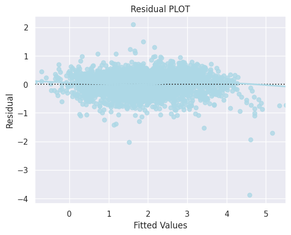

```python
# Predicted values
fitted = model2.fittedvalues

# sns.set_style("whitegrid")
sns.residplot(x = fitted, y = residuals, color = "lightblue", lowess = True)

plt.xlabel("Fitted Values")

plt.ylabel("Residual")

plt.title("Residual PLOT")

plt.show()
```

Residuals are fairly randomly distributed, so that meets the regression assumption

### **4. Normality of error terms**

The residuals should be normally distributed.

```
Shapiro-Wilk Test:
Statistic: 0.9628079533576965, p-value: 1.3338676467636586e-31
Kolmogorov-Smirnov Test:
Statistic: 0.27303233635479096, p-value: 8.522625144041364e-278
```

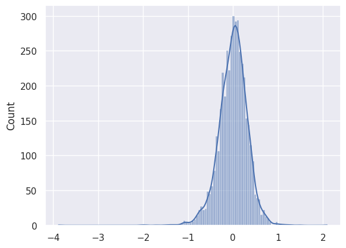

```python
# Plot histogram of residuals
sns.histplot(residuals, kde = True)
from scipy.stats import shapiro, kstest

# Shapiro-Wilk test
stat, p = shapiro(residuals)
print('Shapiro-Wilk Test:')
print(f'Statistic: {stat}, p-value: {p}')

# Kolmogorov-Smirnov test
stat, p = kstest(residuals, 'norm')
print('Kolmogorov-Smirnov Test:')
print(f'Statistic: {stat}, p-value: {p}')
```

Acording to the tests done on the residuals of the model doesn't quite follow a normal distribution.

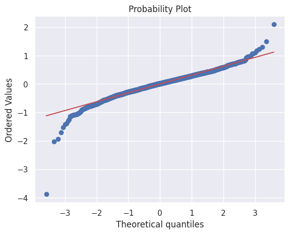

```python
# Plot q-q plot of residuals
import pylab

import scipy.stats as stats

stats.probplot(residuals, dist = "norm", plot = pylab)

plt.show()
```

For Regression Problems, some of the algorithms used are :

**1) Linear Regression**  
**2) Ridge / Lasso Regression**  
**3) Decision Trees**  
**4) Random Forest**

```python
# Function to compute adjusted R-squared
def adj_r2_score(predictors, targets, predictions):
    r2 = r2_score(targets, predictions)
    n = predictors.shape[0]
    k = predictors.shape[1]
    return 1 - ((1 - r2) * (n - 1) / (n - k - 1))


# Function to compute MAPE
def mape_score(targets, predictions):
    return np.mean(np.abs(targets - predictions) / targets) * 100

# Function to compute different metrics to check performance of a regression model
def model_performance_regression(model, predictors, target):
    """
    Function to compute different metrics to check regression model performance

    model: regressor
    predictors: independent variables
    target: dependent variable
    """

    pred = model.predict(predictors)                  # Predict using the independent variables
    r2 = r2_score(target, pred)                       # To compute R-squared
    adjr2 = adj_r2_score(predictors, target, pred)    # To compute adjusted R-squared
    rmse = np.sqrt(mean_squared_error(target, pred))  # To compute RMSE
    mae = mean_absolute_error(target, pred)           # To compute MAE
    mape = mape_score(target, pred)                   # To compute MAPE

    # Creating a dataframe of metrics
    df_perf = pd.DataFrame(
        {
            "RMSE": rmse,
            "MAE": mae,
            "R-squared": r2,
            "Adj. R-squared": adjr2,
            "MAPE": mape,
        },
        index=[0],
    )

    return df_perf
```

```python
# Decision Tree Regressor
dt_regressor = DecisionTreeRegressor(random_state = 1)

# Fitting the model
dt_regressor.fit(X_train, y_train)

# Model Performance on the test data, i.e., prediction
dt_regressor_perf_test = model_performance_regression(dt_regressor, X_test, y_test)

dt_regressor_perf_test
```

|  | RMSE | MAE | R-squared | Adj. R-squared | MAPE |
| --- | --- | --- | --- | --- | --- |
| 0 | 0.308399 | 0.208444 | 0.865899 | 0.864661 | inf |

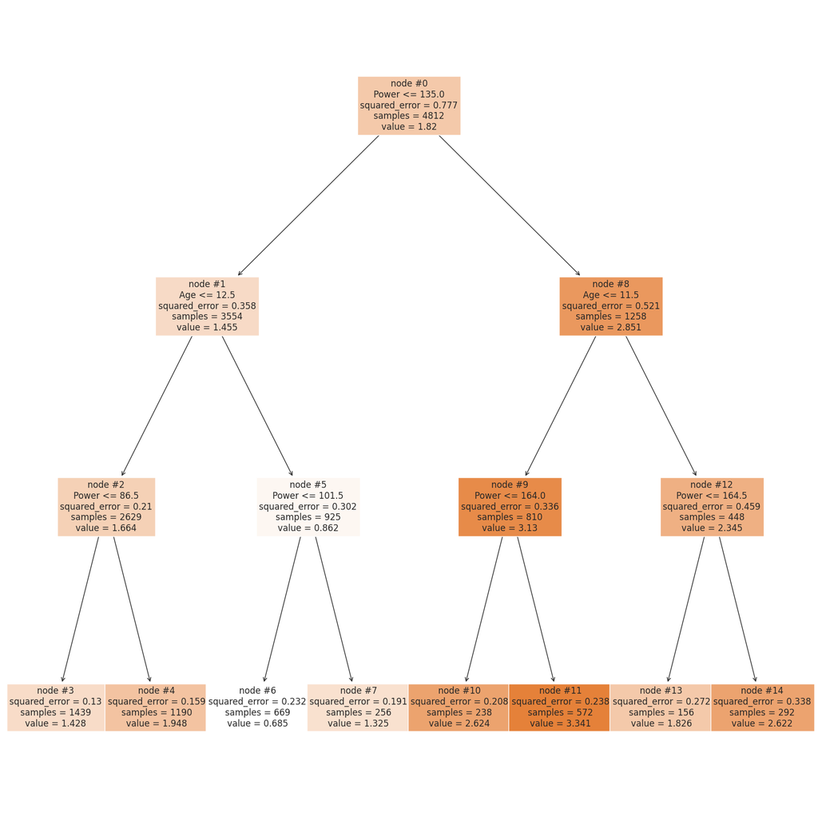

```python
from sklearn import tree
features = list(X.columns)

# Building the model with max_depth=3
dt_regressor_visualize = DecisionTreeRegressor(random_state = 1, max_depth=3)

# Fitting the model
dt_regressor_visualize.fit(X_train, y_train)


plt.figure(figsize = (20, 20))
tree.plot_tree(dt_regressor_visualize, feature_names = features, filled = True, fontsize = 12,
               node_ids = True, class_names = True)
plt.show()
```

```python
print(tree.export_text(dt_regressor_visualize, feature_names=X_train.columns.tolist(), show_weights=True))
```

```
|--- Power <= 135.00
|   |--- Age <= 12.50
|   |   |--- Power <= 86.50
|   |   |   |--- value: [1.43]
|   |   |--- Power >  86.50
|   |   |   |--- value: [1.95]
|   |--- Age >  12.50
|   |   |--- Power <= 101.50
|   |   |   |--- value: [0.69]
|   |   |--- Power >  101.50
|   |   |   |--- value: [1.32]
|--- Power >  135.00
|   |--- Age <= 11.50
|   |   |--- Power <= 164.00
|   |   |   |--- value: [2.62]
|   |   |--- Power >  164.00
|   |   |   |--- value: [3.34]
|   |--- Age >  11.50
|   |   |--- Power <= 164.50
|   |   |   |--- value: [1.83]
|   |   |--- Power >  164.50
|   |   |   |--- value: [2.62]
```

**Let's plot the feature importance and check the most important features.**

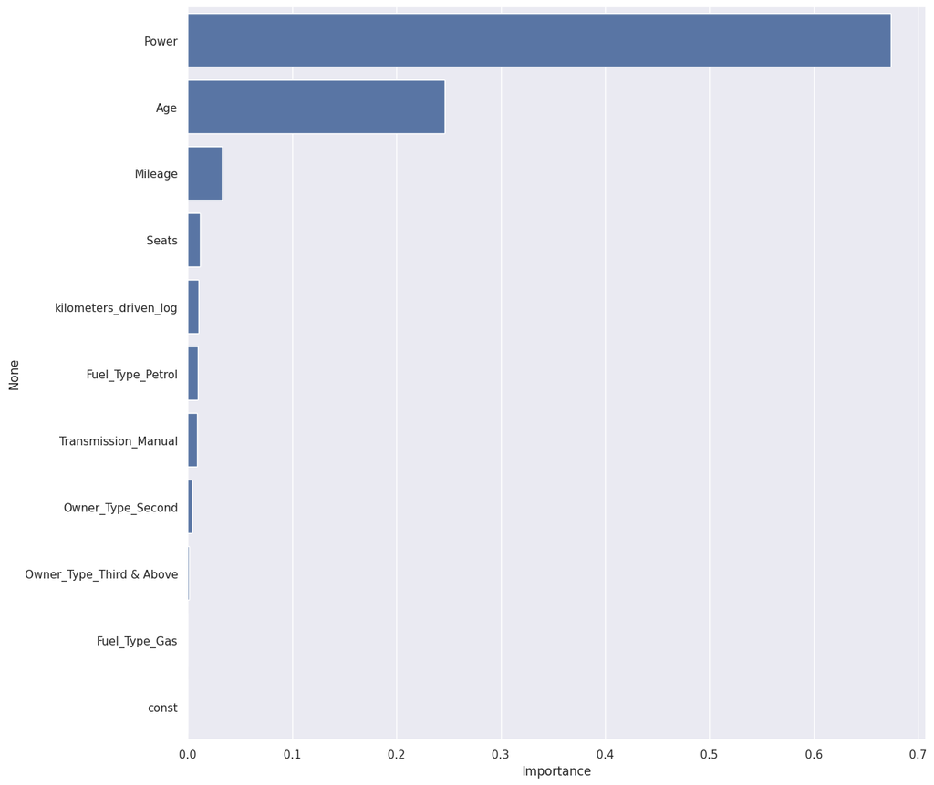

```python
# Feature importance
importances = dt_regressor.feature_importances_

# Rename columns
columns = X.columns

# Create a DataFrame with features importance
importance_df = pd.DataFrame(importances, index = columns, columns = ['Importance']).sort_values(by = 'Importance', ascending = False)

# Plot
plt.figure(figsize = (13, 13))
sns.barplot(x=importance_df.Importance,y=importance_df.index);
```

**Feature importance**

```python
# Bagging Regressor
bagging_estimator = BaggingRegressor(random_state = 1)

# Fitting the model
bagging_estimator.fit(X_train, y_train)

# Model Performance on the test data
bagging_estimator_perf_test = model_performance_regression(bagging_estimator, X_test, y_test)

bagging_estimator_perf_test
```

|  | RMSE | MAE | R-squared | Adj. R-squared | MAPE |
| --- | --- | --- | --- | --- | --- |
| 0 | 0.241404 | 0.177632 | 0.917834 | 0.917075 | inf |

Using the Bagging regressor we get an R-Squared of 0.91, which is better that the initial Decision Tree

```python
# Random Forest Regressor
rf_regressor = RandomForestRegressor(n_estimators = 100, random_state = 1)

# Fitting the model
rf_regressor.fit(X_train, y_train)

# Model Performance on the test data
rf_regressor_perf_test = model_performance_regression(rf_regressor, X_test, y_test)

rf_regressor_perf_test
```

|  | RMSE | MAE | R-squared | Adj. R-squared | MAPE |
| --- | --- | --- | --- | --- | --- |
| 0 | 0.23317 | 0.174819 | 0.923343 | 0.922635 | inf |

We get an initial R-Squared of 0.92 with the Random Forest, it is better than the DT and Bagging regressor

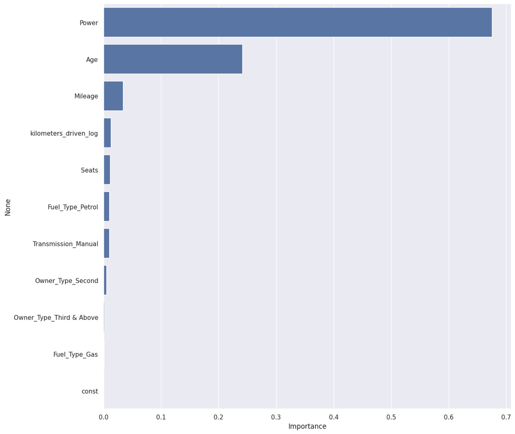

```python
# Feature importance
importances = rf_regressor.feature_importances_

# Rename columns
columns = X.columns

# Create a DataFrame with features importance
importance_df = pd.DataFrame(importances, index = columns, columns = ['Importance']).sort_values(by = 'Importance', ascending = False)

# Plot
plt.figure(figsize = (13, 13))
sns.barplot(x=importance_df.Importance,y=importance_df.index);
```

We get the same most important features than before, showing the same features are adding to the Random Forest model as well

## **AdaBoost**

```python
# Importing AdaBoost Regressor
from sklearn.ensemble import AdaBoostRegressor

# AdaBoost Regressor
ada_regressor = AdaBoostRegressor(random_state=1)

# Fitting the model
ada_regressor.fit(X_train, y_train)

# Model Performance on the test data
ada_regressor_perf_test = model_performance_regression(ada_regressor, X_test, y_test)

ada_regressor_perf_test
```

|  | RMSE | MAE | R-squared | Adj. R-squared | MAPE |
| --- | --- | --- | --- | --- | --- |
| 0 | 0.333005 | 0.262361 | 0.843647 | 0.842203 | inf |

## **Gradient Boosting Regressor**

```python
# Importing Gradient Boosting Regressor
from sklearn.ensemble import GradientBoostingRegressor

# Gradient Boosting Regressor
grad_regressor = GradientBoostingRegressor(random_state=1)

# Fitting the model
grad_regressor.fit(X_train, y_train)

# Model Performance on the test data
grad_regressor_perf_test = model_performance_regression(grad_regressor, X_test, y_test)

grad_regressor_perf_test
```

|  | RMSE | MAE | R-squared | Adj. R-squared | MAPE |
| --- | --- | --- | --- | --- | --- |
| 0 | 0.243812 | 0.186858 | 0.916186 | 0.915412 | inf |

We get an R-Squared of 0.91 using Gradient Boosting Regressor

## **XGBoost Regressor**

```python
# Installing the xgboost library using the 'pip' command
!pip install xgboost
```

```python
# Importing XGBoost Regressor
from xgboost import XGBRegressor

# XGBoost Regressor
xgb = XGBRegressor(random_state = 1)

# Fitting the model
xgb.fit(X_train,y_train)

# Model Performance on the test data
xgb_perf_test = model_performance_regression(xgb, X_test, y_test)

xgb_perf_test
```

|  | RMSE | MAE | R-squared | Adj. R-squared | MAPE |
| --- | --- | --- | --- | --- | --- |
| 0 | 0.213787 | 0.159958 | 0.935558 | 0.934963 | inf |

Using the XGBoost Regressor we get the best R-Squared value of 0.93, this means that this is the model that is perfoming better out of all the ones we have

## **Models' Performance Comparison**

Comparing different machine learning models is an important step in the modeling process, as it allows us to understand the strengths and weaknesses of each model, and to choose the best one for a particular task.

In the context of regression, we can compare models based on various performance metrics, such as **Mean Squared Error (MSE), Root Mean Squared Error (RMSE), Mean Absolute Error (MAE), R-squared, Adjusted R-squared and others**.

```python
model2_perf_test = model_performance_regression(model2, X_test,y_test)
lasso = Lasso(alpha=0.001)
Lasso_model = lasso.fit(X_train, y_train)
Lasso_perf_test = model_performance_regression(Lasso_model,X_test,y_test)

ridge = Ridge(alpha=1.0)
Ridge_model = ridge.fit(X_train, y_train)
Ridge_perf_test = model_performance_regression(Ridge_model,X_test,y_test)
```

```python
models_test_comp_df = pd.concat(
    [
        dt_regressor_perf_test.T,
        bagging_estimator_perf_test.T,
        rf_regressor_perf_test.T,
        ada_regressor_perf_test.T,
        grad_regressor_perf_test.T,
        xgb_perf_test.T,
        model2_perf_test.T,
        Lasso_perf_test.T,
        Ridge_perf_test.T

    ],
    axis = 1,
)

models_test_comp_df.columns = [
    "Decision tree regressor",
    "Bagging Regressor",
    "Random Forest regressor",
    "Ada Boost Regressor",
    "Gradient Boosting Regressor",
    "XG Boost Regressor",
    "Linear regression",
    "Lasso regression",
    "Ridge regression"]

print("Test performance comparison:")

models_test_comp_df.T
```

```
Test performance comparison:
```

|  | RMSE | MAE | R-squared | Adj. R-squared | MAPE |
| --- | --- | --- | --- | --- | --- |
| Decision tree regressor | 0.308399 | 0.208444 | 0.865899 | 0.864661 | inf |
| Bagging Regressor | 0.241404 | 0.177632 | 0.917834 | 0.917075 | inf |
| Random Forest regressor | 0.233170 | 0.174819 | 0.923343 | 0.922635 | inf |
| Ada Boost Regressor | 0.333005 | 0.262361 | 0.843647 | 0.842203 | inf |
| Gradient Boosting Regressor | 0.243812 | 0.186858 | 0.916186 | 0.915412 | inf |
| XG Boost Regressor | 0.213787 | 0.159958 | 0.935558 | 0.934963 | inf |
| Linear regression | 0.288221 | 0.223368 | 0.882874 | 0.881792 | inf |
| Lasso regression | 0.288444 | 0.222958 | 0.882692 | 0.881609 | inf |
| Ridge regression | 0.288487 | 0.223289 | 0.882657 | 0.881573 | inf |

**Feature Importance**

## **Conclusions and Recommendations**

**1. Comparison of various techniques and their relative performance based on chosen Metric (Measure of success):**

- How do different techniques perform? Which one is performing relatively better? Is there scope to improve the performance further?

When evaluating all models within this project, the XG Boost Regressor stands out as the top performer, boasting an impressive R-squared value of 0.93. This signifies that the model effectively captures 93% of the variance present in the dependent variable using the independent features.

The XG Boost Regressor has the lowest RMSE and MAE, indicating that it produces the smallest errors in predictions compared to other models.

The Bagging Regressor and Random Forest Regressor also perform well in terms of accuracy and variance explained, followed by the Gradient Boosting Regressor and Linear Regression.

In summary, the analysis indicates that the XG Boost Regressor outperforms other techniques in terms of accuracy and variance explained. However, there is potential for further improvement through techniques like parameter tuning, exploring different ensemble methods, or enhancing feature engineering processes.

**2. Refined insights:**

- What are the most meaningful insights relevant to the problem?

Looking at our data and all the models that we applied, it is safe to say that Power and Age emerge as the two most important features influencing the price of used cars. Power, representing the maximum power of the engine in bhp, likely reflects the performance and desirability of the vehicle, while Age, indicating the manufacturing year of the car, captures the depreciation factor and overall condition. These insights align with industry expectations, where newer cars with higher power tend to command higher prices in the used car market.

Furthermore, the test performance comparison highlights the superiority of ensemble methods, particularly Random Forest, over traditional linear regression and decision tree models. The Random Forest regressor consistently outperforms in terms of predictive accuracy, as evidenced by its lower RMSE and MAE, and higher R-squared values. This underscores the effectiveness of leveraging ensemble techniques to capture complex relationships and interactions among features, resulting in more accurate price predictions for used cars.

Overall, these insights provide valuable guidance for stakeholders in the automotive industry and the buyers, enabling them to make informed decisions regarding pricing strategies, inventory management, and customer engagement. By understanding the relative importance of features and leveraging advanced modeling techniques, businesses can optimize their pricing strategies and enhance competitiveness in the dynamic used car market.

**3. Proposal for the final solution design:**

- What model do you propose to be adopted? Why is this the best solution to adopt?

**Executive Summary**

This project aims to develop a predictive model for estimating the price of used cars based on various attributes. By leveraging data science techniques, stakeholders in the used car market can gain valuable insights into pricing dynamics, enabling informed decision-making and enhanced market competitiveness.

**Key Features:**

**Power:** This feature, representing the maximum power of the engine in bhp, plays a crucial role in reflecting the performance and desirability of the vehicle. With higher power often correlating to higher car prices, it emerges as one of the most influential attributes in our dataset.

**Age:** Indicating the car's age since its manufacturing year, this feature significantly impacts pricing dynamics. As a general trend, older cars tend to be priced lower, making age a pivotal factor in our predictive model.

**Mileage:** Serving as an indicator of fuel efficiency, mileage expressed in kmpl influences car valuation. Typically, higher mileage values are associated with lower prices, further underscoring the importance of this feature in our analysis.

**Kilometers Driven (Log):** Reflecting the total kilometers driven by previous owners, this feature bears weight in determining car prices. Lower kilometers driven tend to correlate with higher car values, making this a vital aspect in our predictive model.

**Techniques Applied:** Various techniques were employed for analysis and model deployment, including:

**Linear Regression Model:** After feature selection based on VIF scores and P-values, a notable R-squared of 0.87 was achieved.

**Lasso Regression:** With a hyperparameter alpha of 0.001, the model yielded an improved R-squared of 0.882.

**Ridge Regression:** The best R-squared of 0.882 was attained with a hyperparameter alpha of 1.0.

**Random Forest:** Utilizing 100 estimators, the model yielded an R-squared of 0.92.

**Gradient Boosting Regressor:** This technique yielded an R-squared of 0.91.

**XGBoost Regressor:** Outperforming other models, XGBoost Regressor attained the highest R-squared of 0.93.

After rigorous evaluation of the predictive models for used car price estimation, the XGBoost Regressor emerged as the most effective, boasting an impressive R-squared of 0.93. This signifies its superiority in accurately predicting car prices, making it the recommended model for stakeholders seeking reliable pricing insights.

**Problem Solution and Summary**

The problem at hand revolves around the need to accurately estimate the prices of used cars in the market, a critical concern for stakeholders within the automotive industry. Pricing dynamics in the used car market are multifaceted, influenced by factors such as vehicle specifications, age, mileage, and other relevant attributes. However, without a robust predictive model in place, stakeholders face challenges in determining fair and competitive prices for used cars, leading to potential revenue loss, customer dissatisfaction, and market inefficiencies.

The importance of solving this problem cannot be overstated. Accurate pricing not only ensures fair transactions for buyers and sellers but also fosters trust and transparency within the market. Moreover, it enables stakeholders to make informed decisions regarding inventory management, marketing strategies, and overall business operations. In an industry as competitive and dynamic as the automotive market, having a reliable pricing model is paramount to maintaining a competitive edge and maximizing profitability.

In addressing this challenge, we opted for a sophisticated ensemble learning technique known as the XGBoost Regressor, before deploying the model, the duplicates were removed, the missing values and outliers were treated accordingly. This decision was based on several factors. Firstly, XGBoost has demonstrated exceptional performance in a wide range of predictive modeling tasks, particularly in regression problems like the one at hand. Its ability to handle complex relationships between features and predict continuous target variables makes it well-suited for estimating car prices based on various attributes.

Furthermore, the XGBoost Regressor was the best and most accurate model out of 9 that we used for this project. In summary, the adoption of the XGBoost Regressor represents an accurate and strategic solution to the pressing challenge of estimating used car prices accurately. By leveraging advanced data science techniques, we not only address the immediate needs of stakeholders but also lay the foundation for sustained growth and success in the automotive market.

**Recommendations for implementation**

• Stakeholders should integrate the XGBoost Regressor into their existing pricing systems or develop a dedicated platform for price estimation. This integration will allow for seamless access to accurate price predictions based on vehicle attributes.

• Implement robust mechanisms for monitoring and evaluating the performance of the XGBoost model in real-world scenarios. Track key metrics such as prediction accuracy, model stability, and customer feedback. Continuously refine the model based on feedback and evolving market dynamics.